# **Project 1: Cardio Good Fitness Project**

**Name:** Adam DiStefano

**Date:** March 2022

**Subject:** Exploratory Data Analysis (EDA)

# *Problem Statement*

Explore the dataset to identify differences between the customers of each product. You can also explore relationships between the different attributes of the customers. You can approach it from any other line of questioning that you feel could be relevant for the business. The idea is to get you comfortable working in Python.

You are expected to do the following :

1. Come up with a customer profile (characteristics of a customer) of the different products.
2. Perform univariate and multivariate analyses.
3. Generate a set of insights and recommendations that will help the company in targeting new customers.

**Data Dictionary**

- **Product** - The model no. of the treadmill
- **Age** - Age of the customer in no of years
- **Gender** - Gender of the customer
- **Education** - Education of the customer in no. of years
- **Marital Status** - Marital status of the customer
- **Usage** - Avg. # times the customer wants to use the treadmill every week
- **Fitness** - Self rated fitness score of the customer (5 - very fit, 1 - very unfit)
- **Income** - Income of the customer
- **Miles** - Miles that a customer expects to run

## **Import Libraries**

```python
#import NumPy for arrays
import numpy as np

#import pandas for DataFrames
import pandas as pd

#import matplotlib, seaborn, and plotly for data visualizations
import matplotlib as plt
import seaborn as sns
import plotly.express as px

#to show visualizations in notebook
%matplotlib inline

#set floats to only display 3 digits
pd.set_option('display.float_format', lambda x: '%.3f' %x)
```

```python
#mount and connect Google Drive
from google.colab import drive
drive.mount('/content/drive')

#Import dataset "CardioGoodFitness.csv"
data = pd.read_csv('/content/drive/My Drive/Colab Notebooks/CardioGoodFitness.csv')
```

## **About the Dataset**

```python
#return first (5) rows in the dataset
data.head()
```

|  | Product | Age | Gender | Education | MaritalStatus | Usage | Fitness | Income | Miles |
| --- | --- | --- | --- | --- | --- | --- | --- | --- | --- |
| 0 | TM195 | 18 | Male | 14 | Single | 3 | 4 | 29562 | 112 |
| 1 | TM195 | 19 | Male | 15 | Single | 2 | 3 | 31836 | 75 |
| 2 | TM195 | 19 | Female | 14 | Partnered | 4 | 3 | 30699 | 66 |
| 3 | TM195 | 19 | Male | 12 | Single | 3 | 3 | 32973 | 85 |
| 4 | TM195 | 20 | Male | 13 | Partnered | 4 | 2 | 35247 | 47 |

There are 9 columns (not including the index):

1. Product
2. Age
3. Gender
4. Education
5. Marital Status
6. Usage
7. Fitness
8. Income
9. Miles

```python
#return last (5) rows in dataset
data.tail()
```

|  | Product | Age | Gender | Education | MaritalStatus | Usage | Fitness | Income | Miles |
| --- | --- | --- | --- | --- | --- | --- | --- | --- | --- |
| 175 | TM798 | 40 | Male | 21 | Single | 6 | 5 | 83416 | 200 |
| 176 | TM798 | 42 | Male | 18 | Single | 5 | 4 | 89641 | 200 |
| 177 | TM798 | 45 | Male | 16 | Single | 5 | 5 | 90886 | 160 |
| 178 | TM798 | 47 | Male | 18 | Partnered | 4 | 5 | 104581 | 120 |
| 179 | TM798 | 48 | Male | 18 | Partnered | 4 | 5 | 95508 | 180 |

There is 180 rows in the dataset based on the index value.

```python
#return number of rows and columns in dataset
data.shape
```

```
(180, 9)
```

This command confirms that there are 180 rows with 9 columns.

```python
#Show all the unique value counts in each row, presented in a dataframe
unique_values = pd.DataFrame(data.nunique())
unique_values
```

|  | 0 |
| --- | --- |
| Product | 3 |
| Age | 32 |
| Gender | 2 |
| Education | 8 |
| MaritalStatus | 2 |
| Usage | 6 |
| Fitness | 5 |
| Income | 62 |
| Miles | 37 |

- Income has the largest amount of unique values, followed by miles and age, respectively
- Marital Status and gender have the least amount of unique values with (2)

```python
#returns the datatypes, columns, non-null values, indexes, and memory usage
data.info()
```

```
<class 'pandas.core.frame.DataFrame'>
RangeIndex: 180 entries, 0 to 179
Data columns (total 9 columns):
 #   Column         Non-Null Count  Dtype
---  ------         --------------  -----
 0   Product        180 non-null    object
 1   Age            180 non-null    int64
 2   Gender         180 non-null    object
 3   Education      180 non-null    int64
 4   MaritalStatus  180 non-null    object
 5   Usage          180 non-null    int64
 6   Fitness        180 non-null    int64
 7   Income         180 non-null    int64
 8   Miles          180 non-null    int64
dtypes: int64(6), object(3)
memory usage: 12.8+ KB
```

The data consists of six int64 and three object datatypes. According to this, there is no null data. We will verify that below. Additionally, the memory usage is returned.

```python
#returns (and validates finding above) all the null values
pd.DataFrame(data.isnull().sum())
```

|  | 0 |
| --- | --- |
| Product | 0 |
| Age | 0 |
| Gender | 0 |
| Education | 0 |
| MaritalStatus | 0 |
| Usage | 0 |
| Fitness | 0 |
| Income | 0 |
| Miles | 0 |

As identified previously, there does not appear to be any missing/null data.

```python
#returns the statistical summary for the dataset
data.describe().T
```

|  | count | mean | std | min | 25% | 50% | 75% | max |
| --- | --- | --- | --- | --- | --- | --- | --- | --- |
| Age | 180 | 29 | 7 | 18 | 24 | 26 | 33 | 50 |
| Education | 180 | 16 | 2 | 12 | 14 | 16 | 16 | 21 |
| Usage | 180 | 3 | 1 | 2 | 3 | 3 | 4 | 7 |
| Fitness | 180 | 3 | 1 | 1 | 3 | 3 | 4 | 5 |
| Income | 180 | 53720 | 16507 | 29562 | 44059 | 50596 | 58668 | 104581 |
| Miles | 180 | 103 | 52 | 21 | 66 | 94 | 115 | 360 |

```python
#returns the correlation between each column
data.corr()
```

|  | Age | Education | Usage | Fitness | Income | Miles |
| --- | --- | --- | --- | --- | --- | --- |
| Age | 1.000 | 0.280 | 0.015 | 0.061 | 0.513 | 0.037 |
| Education | 0.280 | 1.000 | 0.395 | 0.411 | 0.626 | 0.307 |
| Usage | 0.015 | 0.395 | 1.000 | 0.669 | 0.520 | 0.759 |
| Fitness | 0.061 | 0.411 | 0.669 | 1.000 | 0.535 | 0.786 |
| Income | 0.513 | 0.626 | 0.520 | 0.535 | 1.000 | 0.543 |
| Miles | 0.037 | 0.307 | 0.759 | 0.786 | 0.543 | 1.000 |

- Highest correlation between fitness and miles at 0.786 and miles and usage at 0.759 respectively
- The smallest correlation is between usage and age at 0.015

# **Univariate Analysis**

*Product Model Distribution*

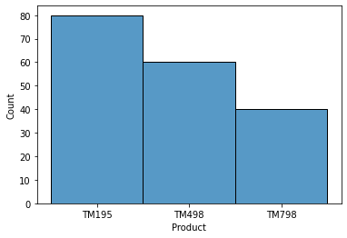

```python
#Histogram of the treadmill product
sns.histplot(data=data, x='Product');
```

```python
#Value counts of the product
pd.DataFrame(data['Product'].value_counts())
```

|  | Product |
| --- | --- |
| TM195 | 80 |
| TM498 | 60 |
| TM798 | 40 |

There are three models of treadmills. There are eighty TM195 models, sixty TM498 models, and forty TM798 models.

- 44.4% of the models are a TM195
- 33.3% of the models are a TM498
- 22.2% of the models are TM798

```python
#Review statisical analysis of the TM195 model
data[data['Product'] == 'TM195'].describe().T
```

|  | count | mean | std | min | 25% | 50% | 75% | max |
| --- | --- | --- | --- | --- | --- | --- | --- | --- |
| Age | 80 | 29 | 7 | 18 | 23 | 26 | 33 | 50 |
| Education | 80 | 15 | 1 | 12 | 14 | 16 | 16 | 18 |
| Usage | 80 | 3 | 1 | 2 | 3 | 3 | 4 | 5 |
| Fitness | 80 | 3 | 1 | 1 | 3 | 3 | 3 | 5 |
| Income | 80 | 46418 | 9076 | 29562 | 38658 | 46617 | 53439 | 68220 |
| Miles | 80 | 83 | 29 | 38 | 66 | 85 | 94 | 188 |

```python
#Review statisical analysis of the TM498 model
data[data['Product'] == 'TM498'].describe().T
```

|  | count | mean | std | min | 25% | 50% | 75% | max |
| --- | --- | --- | --- | --- | --- | --- | --- | --- |
| Age | 60 | 29 | 7 | 19 | 24 | 26 | 33 | 48 |
| Education | 60 | 15 | 1 | 12 | 14 | 16 | 16 | 18 |
| Usage | 60 | 3 | 1 | 2 | 3 | 3 | 3 | 5 |
| Fitness | 60 | 3 | 1 | 1 | 3 | 3 | 3 | 4 |
| Income | 60 | 48974 | 8654 | 31836 | 44912 | 49460 | 53439 | 67083 |
| Miles | 60 | 88 | 33 | 21 | 64 | 85 | 106 | 212 |

```python
#Review statisical analysis of the TM195 model
data[data['Product'] == 'TM798'].describe().T
```

|  | count | mean | std | min | 25% | 50% | 75% | max |
| --- | --- | --- | --- | --- | --- | --- | --- | --- |
| Age | 40 | 29 | 7 | 22 | 25 | 27 | 30 | 48 |
| Education | 40 | 17 | 2 | 14 | 16 | 18 | 18 | 21 |
| Usage | 40 | 5 | 1 | 3 | 4 | 5 | 5 | 7 |
| Fitness | 40 | 5 | 1 | 3 | 4 | 5 | 5 | 5 |
| Income | 40 | 75442 | 18506 | 48556 | 58205 | 76568 | 90886 | 104581 |
| Miles | 40 | 167 | 60 | 80 | 120 | 160 | 200 | 360 |

*Gender Distribution*

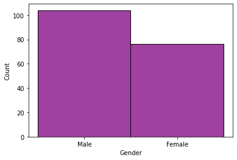

```python
#Histogram of gender breakdown
sns.histplot(data['Gender'], color='purple');
```

```python
#Value counnts of gender
pd.DataFrame(data['Gender'].value_counts())
```

|  | Gender |
| --- | --- |
| Male | 104 |
| Female | 76 |

The dataset consists of approximately 58% males and 42% females.

```python
#Review statisical analysis of males
data[data['Gender'] == 'Male'].describe().T
```

|  | count | mean | std | min | 25% | 50% | 75% | max |
| --- | --- | --- | --- | --- | --- | --- | --- | --- |
| Age | 104 | 29 | 7 | 18 | 24 | 26 | 34 | 48 |
| Education | 104 | 16 | 2 | 12 | 14 | 16 | 16 | 21 |
| Usage | 104 | 4 | 1 | 2 | 3 | 4 | 4 | 7 |
| Fitness | 104 | 4 | 1 | 1 | 3 | 3 | 4 | 5 |
| Income | 104 | 56563 | 18422 | 29562 | 45480 | 52302 | 61611 | 104581 |
| Miles | 104 | 113 | 55 | 42 | 85 | 100 | 141 | 360 |

```python
#Review statisical analysis of males
data[data['Gender'] == 'Female'].describe().T
```

|  | count | mean | std | min | 25% | 50% | 75% | max |
| --- | --- | --- | --- | --- | --- | --- | --- | --- |
| Age | 76 | 29 | 6 | 19 | 24 | 26 | 33 | 50 |
| Education | 76 | 15 | 1 | 13 | 14 | 16 | 16 | 21 |
| Usage | 76 | 3 | 1 | 2 | 2 | 3 | 4 | 6 |
| Fitness | 76 | 3 | 1 | 1 | 3 | 3 | 3 | 5 |
| Income | 76 | 49829 | 12558 | 30699 | 42922 | 47754 | 53796 | 95866 |
| Miles | 76 | 90 | 45 | 21 | 66 | 85 | 100 | 280 |

- The mean of usage shows that men use the treadmills more than women
- Men also rank their fitness level higher than women
- Women run between 21-280 miles where men run between 42-360 miles

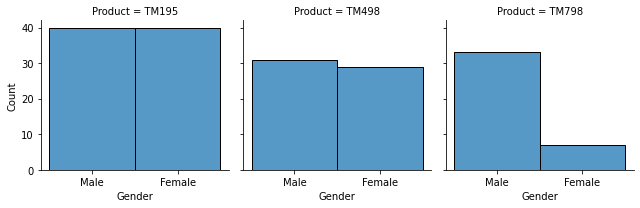

```python
#FacetGrid view of gender based on treadmill model
gender = sns.FacetGrid(data, col="Product")
gender.map(sns.histplot, "Gender");
```

*Miles Distribution*

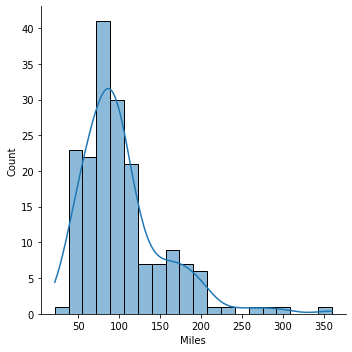

```python
#Distplot of miles
sns.displot(x=data['Miles'], kde=True);
```

```python
#Mean number of miles
data['Miles'].mean()
```

```
103.19444444444444
```

The mean miles ran in the dataset is 103.2 miles.

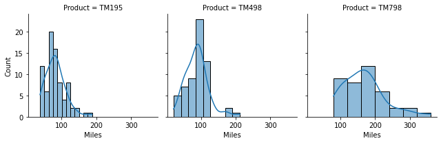

```python
#FacetGrid view of miles based on treadmill model
miles = sns.FacetGrid(data, col="Product")
miles.map(sns.histplot, "Miles", kde=True);
```

Customers who run the most amount of miles almost exclusively use the TM798 model.

*Education Distribution*

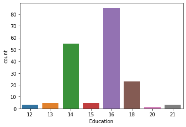

```python
#Countplot of education
sns.countplot(data=data, x='Education');
```

```python
#Value counts of education
pd.DataFrame(data['Education'].value_counts(ascending=True).sort_index())
```

|  | Education |
| --- | --- |
| 12 | 3 |
| 13 | 5 |
| 14 | 55 |
| 15 | 5 |
| 16 | 85 |
| 18 | 23 |
| 20 | 1 |
| 21 | 3 |

```python
#Mean level of education
data['Education'].mean()
```

```
15.572222222222223
```

The mean education level of the customers in the dataset is a college level education with 15.6 years.

```python
#Median level of education
data['Education'].median()
```

```
16.0
```

The median education level is a college education (16 years).

```python
#Mode level of education
data['Education'].mode()
```

```
0    16
dtype: int64
```

The mode for education level is a college education (16 years).

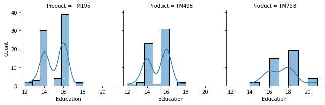

```python
#FacetGrid view of education based on treadmill model
education = sns.FacetGrid(data, col="Product")
education.map(sns.histplot, "Education", kde=True);
```

*Usage Distribution*

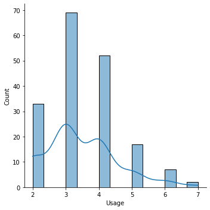

```python
#Displot of the usage
sns.displot(data=data, x='Usage', kde=True);
```

```python
#Mean of usage
data['Usage'].mean()
```

```
3.4555555555555557
```

The majority of customers intend to use the treadmill 3-4 times per week.

```python
#Value counts of usage
pd.DataFrame(data['Usage'].value_counts().sort_index())
```

|  | Usage |
| --- | --- |
| 2 | 33 |
| 3 | 69 |
| 4 | 52 |
| 5 | 17 |
| 6 | 7 |
| 7 | 2 |

- 18.3% of the customers intend to use the treadmill 2 times per week
- 38.3% of the customers intend to use the treadmill 3 times per week
- 28.9% of the customers intend to use the treadmill 4 times per week
- 14.4% of the customers intend to use the treadmill more than 4 times per week

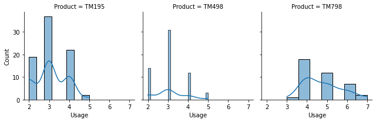

```python
#FacetGrid view of usage based on treadmill model
usage = sns.FacetGrid(data, col="Product")
usage.map(sns.histplot, "Usage", kde=True);
```

*Marital Status Distribution*

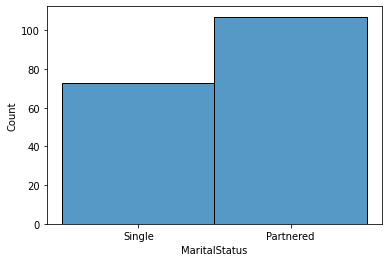

```python
#Histplot of marital status
sns.histplot(data=data, x='MaritalStatus');
```

```python
#Values of marital status
pd.DataFrame(data['MaritalStatus'].value_counts())
```

|  | MaritalStatus |
| --- | --- |
| Partnered | 107 |
| Single | 73 |

59% of customers are partnered.

```python
#Marital status breakdown by product
pd.DataFrame(data[['MaritalStatus', 'Product']].value_counts(ascending=True).sort_index())
```

| MaritalStatus | Product | 0 |
| --- | --- | --- |
| Partnered | TM195 | 48 |
|  | TM498 | 36 |
|  | TM798 | 23 |
| Single | TM195 | 32 |
|  | TM498 | 24 |
|  | TM798 | 17 |

**TM195**

- 44% of single customers use the TM195
- 44% of partnered customers use the TM195

**TM498**

- 33% of single customers use the TM498
- 33% of partnered customers use the TM498

**TM798**

- 24% of single customers use the TM798
- 22% of partnered customers use the TM798

There is no real siginificant diffence of treadmill sselection based on marital status.

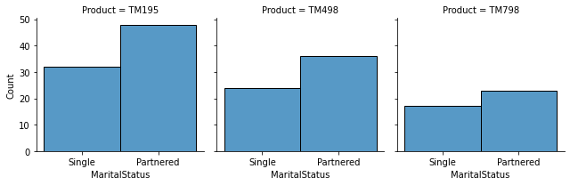

```python
#FacetGrid view of marital status based on treadmill model
marital = sns.FacetGrid(data, col="Product")
marital.map(sns.histplot, "MaritalStatus");
```

*Age Distribution*

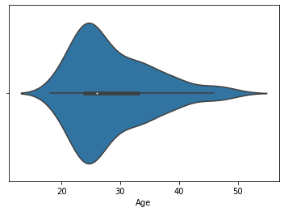

```python
#Violin plot of ages
sns.violinplot(x=data['Age']);
```

```python
#Minimum age in dataset
data["Age"].min()
```

```
18
```

The minimum age is 18 in the dataset

```python
#Maximum age in dataset
data["Age"].max()
```

```
50
```

The maximum age is 50 years old

```python
#Mean of age
data["Age"].mean()
```

```
28.788888888888888
```

The mean age is approximately 29 years old

```python
#Median of age
data['Age'].median()
```

```
26.0
```

The median age is 26 years old.

```python
#Mode of age
data['Age'].mode()
```

```
0    25
dtype: int64
```

The most common age of the customers is 25 years old.

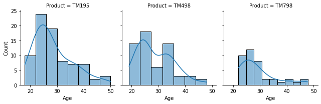

```python
#FacetGrid view of age based on treadmill model
age = sns.FacetGrid(data, col="Product")
age.map(sns.histplot, "Age", kde=True);
```

More customers between 25-30 years old buy the TM195 model.

*Fitness Distribution*

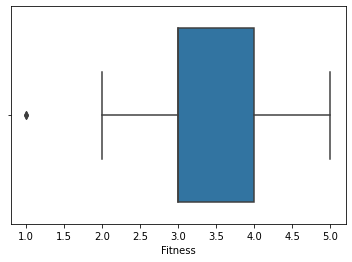

```python
#Boxplot of self fitness score
sns.boxplot(data=data, x='Fitness');
```

We will drop the outliers.

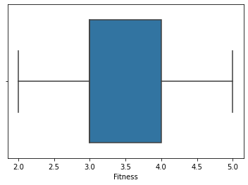

```python
#Boxplot of self fitness score
sns.boxplot(data=data, x='Fitness', showfliers=False);
```

```python
#Value counts of self fitness level score
pd.DataFrame(data['Fitness'].value_counts().sort_index())
```

|  | Fitness |
| --- | --- |
| 1 | 2 |
| 2 | 26 |
| 3 | 97 |
| 4 | 24 |
| 5 | 31 |

- 1.1% of customers ranked their fitness level at a 1
- 14.4% of customers ranked their fitness level at a 2
- 53.9% of customers ranked their fitness level at a 3
- 13.3% of customers ranked their fitness level at a 4
- 17.2% of customers ranked their fitness level at a 5

```python
#Mean of the self fitness level ranking
data['Fitness'].mean()
```

```
3.311111111111111
```

```python
#Review statisical analysis of fitness score 1
data[data['Fitness'] == 1].describe().T
```

|  | count | mean | std | min | 25% | 50% | 75% | max |
| --- | --- | --- | --- | --- | --- | --- | --- | --- |
| Age | 2.000 | 27.000 | 5.657 | 23.000 | 25.000 | 27.000 | 29.000 | 31.000 |
| Education | 2.000 | 17.000 | 1.414 | 16.000 | 16.500 | 17.000 | 17.500 | 18.000 |
| Usage | 2.000 | 2.500 | 0.707 | 2.000 | 2.250 | 2.500 | 2.750 | 3.000 |
| Fitness | 2.000 | 1.000 | 0.000 | 1.000 | 1.000 | 1.000 | 1.000 | 1.000 |
| Income | 2.000 | 51939.000 | 18782.170 | 38658.000 | 45298.500 | 51939.000 | 58579.500 | 65220.000 |
| Miles | 2.000 | 34.000 | 18.385 | 21.000 | 27.500 | 34.000 | 40.500 | 47.000 |

- There are only 2 customers who rated their fitness level with a score of 1
- The mean age for customers ranking their fitness level a (1) is 27 years old
- These customers only use the treadmills 3 times a week at a maximum
- They run between 21-47 miles
- They earn an income between \$38,658 - $65,220

```python
#Review statisical analysis of fitness score 2
data[data['Fitness'] == 2].describe().T
```

|  | count | mean | std | min | 25% | 50% | 75% | max |
| --- | --- | --- | --- | --- | --- | --- | --- | --- |
| Age | 26.000 | 28.269 | 6.885 | 20.000 | 23.250 | 25.500 | 32.500 | 46.000 |
| Education | 26.000 | 14.731 | 1.218 | 12.000 | 14.000 | 14.000 | 16.000 | 16.000 |
| Usage | 26.000 | 2.538 | 0.647 | 2.000 | 2.000 | 2.000 | 3.000 | 4.000 |
| Fitness | 26.000 | 2.000 | 0.000 | 2.000 | 2.000 | 2.000 | 2.000 | 2.000 |
| Income | 26.000 | 46179.692 | 7825.183 | 32973.000 | 40932.000 | 45480.000 | 53154.750 | 60261.000 |
| Miles | 26.000 | 51.692 | 11.825 | 38.000 | 43.250 | 47.000 | 53.000 | 85.000 |

- There are 26 customers who have ranked their fitness level a 2
- The mean age for customers ranking their fitness level a (2) is 28 years old
- These customers use the treadmills 4 times a week at a maximum
- They run between 38-85 miles
- They earn an income between \$32,793 - $60,261

```python
#Review statisical analysis of fitness score 3
data[data['Fitness'] == 3].describe().T
```

|  | count | mean | std | min | 25% | 50% | 75% | max |
| --- | --- | --- | --- | --- | --- | --- | --- | --- |
| Age | 97 | 29 | 7 | 19 | 23 | 26 | 33 | 50 |
| Education | 97 | 15 | 1 | 12 | 14 | 16 | 16 | 21 |
| Usage | 97 | 3 | 1 | 2 | 3 | 3 | 4 | 5 |
| Fitness | 97 | 3 | 0 | 3 | 3 | 3 | 3 | 3 |
| Income | 97 | 48853 | 10342 | 30699 | 40932 | 48891 | 54576 | 88396 |
| Miles | 97 | 87 | 19 | 53 | 75 | 85 | 95 | 170 |

- Their are 97 customers ranking their fitness level a 3
- The mean age for customers ranking their fitness level a (3) is 29 years old
- These customers use the treadmills 5 times a week at a maximum
- They run between 53-170 miles
- They earn an income between \$30,699 - $88,396

```python
#Review statisical analysis of fitness score 4
data[data['Fitness'] == 4].describe().T
```

|  | count | mean | std | min | 25% | 50% | 75% | max |
| --- | --- | --- | --- | --- | --- | --- | --- | --- |
| Age | 24.000 | 28.333 | 6.532 | 18.000 | 25.000 | 26.000 | 32.250 | 44.000 |
| Education | 24.000 | 15.792 | 1.933 | 13.000 | 14.000 | 16.000 | 16.500 | 21.000 |
| Usage | 24.000 | 3.917 | 0.929 | 3.000 | 3.000 | 4.000 | 5.000 | 6.000 |
| Fitness | 24.000 | 4.000 | 0.000 | 4.000 | 4.000 | 4.000 | 4.000 | 4.000 |
| Income | 24.000 | 54995.292 | 18304.282 | 29562.000 | 44058.750 | 49459.500 | 59905.750 | 103336.000 |
| Miles | 24.000 | 131.625 | 37.624 | 74.000 | 106.000 | 127.000 | 160.000 | 212.000 |

- Ther are 24 customers ranking their fitness level a 4
- The mean age for customers ranking their fitness level a (4) is 28 years old
- These customers use the treadmills 6 times a week at a maximum
- They run between 74-212 miles
- They earn an income between \$29,562 - $103,336

```python
#Review statisical analysis of fitness score 5
data[data['Fitness'] == 5].describe().T
```

|  | count | mean | std | min | 25% | 50% | 75% | max |
| --- | --- | --- | --- | --- | --- | --- | --- | --- |
| Age | 31.000 | 29.806 | 7.296 | 22.000 | 24.000 | 28.000 | 33.500 | 48.000 |
| Education | 31.000 | 17.065 | 1.436 | 14.000 | 16.000 | 16.000 | 18.000 | 21.000 |
| Usage | 31.000 | 4.839 | 1.003 | 3.000 | 4.000 | 5.000 | 5.500 | 7.000 |
| Fitness | 31.000 | 5.000 | 0.000 | 5.000 | 5.000 | 5.000 | 5.000 | 5.000 |
| Income | 31.000 | 74396.710 | 19866.024 | 44343.000 | 53536.000 | 77191.000 | 91508.500 | 104581.000 |
| Miles | 31.000 | 178.935 | 60.291 | 80.000 | 150.000 | 170.000 | 200.000 | 360.000 |

- Their are 31 customers ranking their fitness level a 5
- These customers use the treadmills 7 times a week at a maximum
- They run between 80-360 miles
- They earn an income between \$44,343 - $104,581

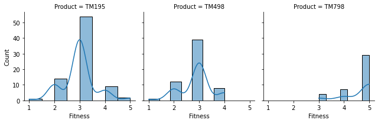

```python
#FacetGrid view of fitness based on treadmill model
fitness = sns.FacetGrid(data, col="Product")
fitness.map(sns.histplot, "Fitness", kde=True);
```

*Income Distribution*

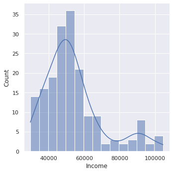

```python
#Distribution plot of the income data
sns.displot(x=data['Income'], kde=True);
```

The majority of cutomers make less than $70,000 per year. The incomes are also slightly positively skewed.

```python
#Calculating the mean income
data['Income'].mean()
```

```
53719.57777777778
```

The mean income is approximately how $54,000 a year, but mean is rarely used in calculating the average income. Median is a better measure for the income average.

```python
#Calculating the median income (a better measure of the average salary)
data['Income'].median()
```

```
50596.5
```

The median income is approximately $50,600 annually.

```python
#Calculating the mode income (a better measure of the average salary)
data['Income'].mode()
```

```
0    45480
dtype: int64
```

The mode of income is approximately $45,500 annually.

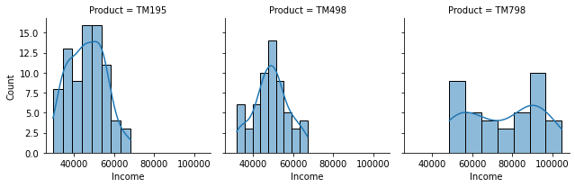

```python
#FacetGrid view of imcome based on treadmill model
income = sns.FacetGrid(data, col="Product")
income.map(sns.histplot, "Income", kde=True);
```

# **Multivariate Analysis**

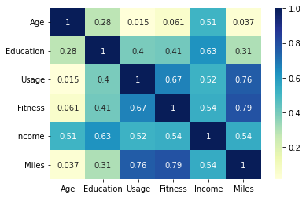

```python
#Heatmap/Visual representation of the correlation
sns.heatmap(data=data[['Product', 'Age', 'Gender', 'Education', 'MaritalStatus', 'Usage', 'Fitness', 'Income','Miles']].corr(), annot=True, cmap='YlGnBu');
```

The top three corrleations are between:

- Fitness and miles
- Usage and Miles
- Fitness and usage

We will visualize these below.

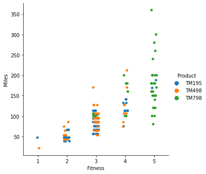

```python
#Catplot of fitness and miles by product
sns.catplot(data=data, x='Fitness', y='Miles', hue='Product');
```

- Customers who rank themselves least physically fit (1-2 ratings) exclusively use the TM195 and TM498 models of treadmills
- Customers who rank themselves most physically fit (5 rating) almost exclusively use the TM798 model
- Customers running the most amount of miles use the TM798 where customers running the least use the TM195 and TM498

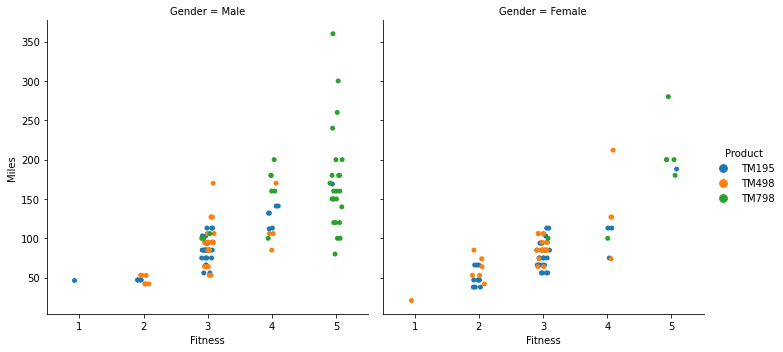

```python
#Catplot of fitness and miles by product, broken down by gender
sns.catplot(data=data, x='Fitness', y='Miles', hue='Product', col='Gender');
```

- More males than females rank their fitness higher, run more miles, and almost exclusively use the TM798
- Women who rank themselves lower in terms of fitness (1-2 rating) use the TM195 and TM498 models, respectively.
- Significantly less women use the TM798 as compared to men.

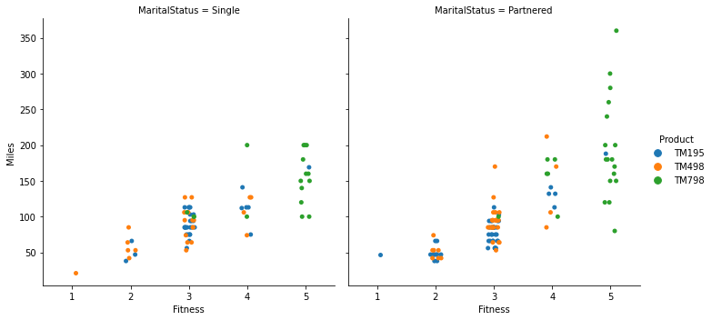

```python
#Catplot of fitness and miles by product, broken down by marital status
sns.catplot(data=data, x='Fitness', y='Miles', hue='Product', col='MaritalStatus');
```

- Fitness ratings of 3 or less (whether single or partnered) almost exclusively use the TM195 or TM498 models.
- More single customers with a fitness rating of 3 use the TM798 than the partnered customers with the same fitness rating.
- There are more partnered couples using the TM798 wh rank there fitness level a 4 or 5.
- Partnered customers with the highest fitness score run more miles.

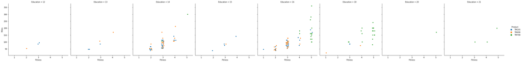

```python
#Catplot of fitness and miles by product, broken down by education
sns.catplot(data=data, x='Fitness', y='Miles', hue='Product', col='Education', height=5, aspect=1);
```

- Customers with more education prefer the TM798 model and rank their fitness levels higher than those with less education and run more miles
- Customers with 12-13 years of education do not use the TM798 model

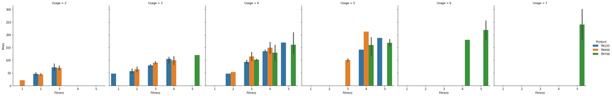

```python
#Catplot of fitness and miles by product, broken down by usage
sns.catplot(data=data, x='Fitness', y='Miles', hue='Product', col='Usage', height=5, aspect=1, kind='bar');
```

- Customers who use the treadmills most rank their fitness levels higher, run more miles, and prefer the TM798 model
- Customers who use the treadmill the least not only rank their fitness levels lower and run less miles, they mainly use the TM195 and TM498 models.

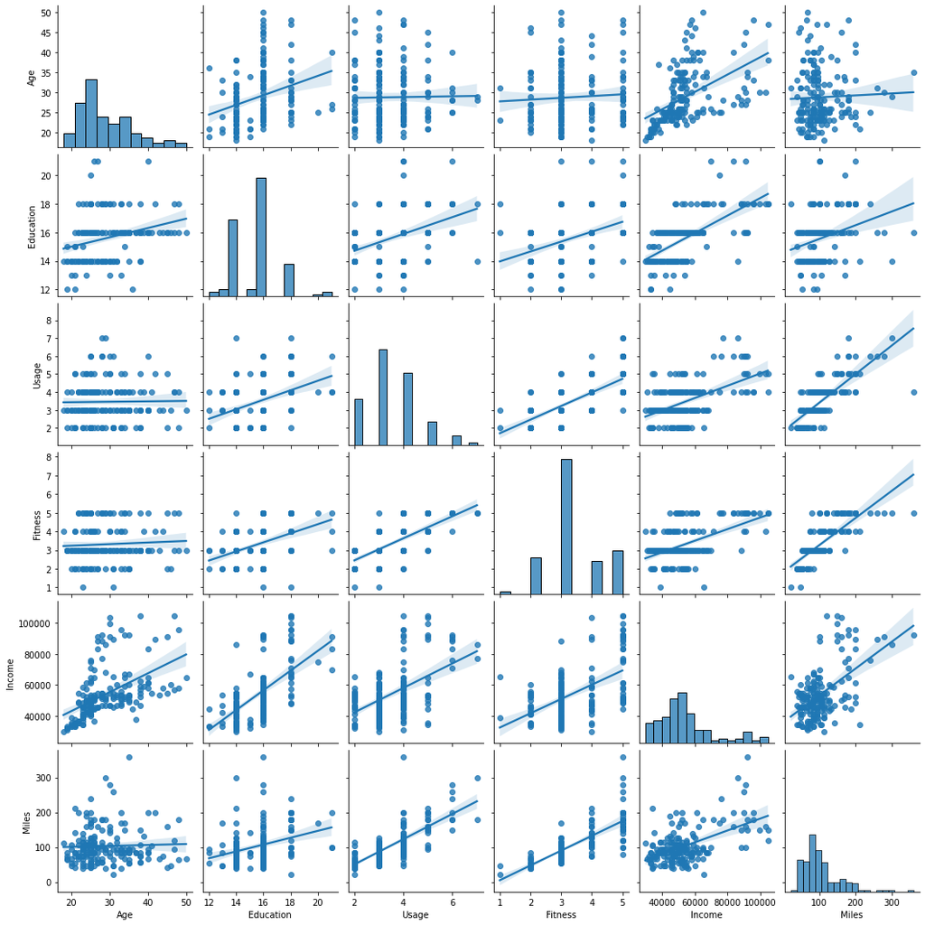

```python
sns.pairplot(data, kind = 'reg');
```

```python
#Dataframe of mean age by product
pd.DataFrame(data.groupby('Product')['Age'].mean())
```

| Product | Age |
| --- | --- |
| TM195 | 28.550 |
| TM498 | 28.900 |
| TM798 | 29.100 |

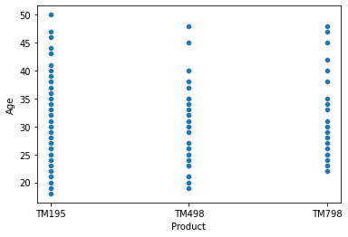

```python
#Scatterplot of product by age
sns.scatterplot(data=data, x='Product', y='Age');
```

There is minimal variance in mean age when choosing a treadmill model

```python
#Dataframe of usage age by usage
pd.DataFrame(data.groupby('Usage')['Age'].mean())
```

| Usage | Age |
| --- | --- |
| 2 | 28.485 |
| 3 | 28.986 |
| 4 | 28.538 |
| 5 | 29.059 |
| 6 | 29.571 |
| 7 | 28.500 |

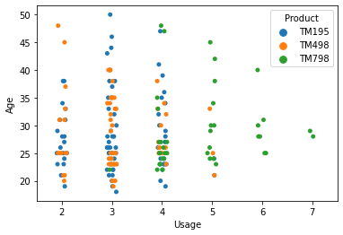

```python
#Stripplot of usage and age based by product
sns.stripplot(data=data, x='Usage', y=data['Age'], hue='Product');
```

- There is no significant differences of age based on usage
- Older people use the treadmills between 2-3 times per week
- Customers using the treadmill 4 or more times per week, between the ages of 23-30 prefer the TM798 model

```python
#Dataframe of mean age by fitness level
pd.DataFrame(data.groupby('Fitness')['Age'].mean())
```

| Fitness | Age |
| --- | --- |
| 1 | 27.000 |
| 2 | 28.269 |
| 3 | 28.753 |
| 4 | 28.333 |
| 5 | 29.806 |

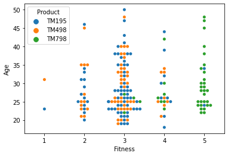

```python
#Swarmplot of fitness and age base on product
sns.swarmplot(data=data, x='Fitness', y='Age', hue='Product');
```

There is very little difference in mean ages based on fitness scores (27-30 years old)

```python
#Dataframe of median of the product by income
pd.DataFrame(data.groupby('Product')['Income'].median())
```

| Product | Income |
| --- | --- |
| TM195 | 46617.000 |
| TM498 | 49459.500 |
| TM798 | 76568.500 |

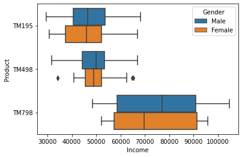

```python
#Boxplot of income
sns.boxplot(data=data, x='Income', y='Product', hue='Gender');
```

- The largest variance between male and female mean salary is with the TM798
- There are outliers for female customer income with regards to the TM498 model